# Malnutrition in Africa - A Study

### Research Question 2

Is there a relationship between a country's Gross Domestic Product (GDP) and its malnutrition rate?

### GDP`

GDP is obtained from world data bank and it can be seen that the first few rows are not actual data, those are some details in the file. Dropping these rows.

###### This sheet in the file consist of rate of growth or decline in percentage when compared to previous years

```python
#GLobal
df_gdpRate = pd.read_excel(r'GDP/Data_Extract_From_World_Development_Indicators-3.xlsx', sheet_name='AnnualGrowth')
df_gdpRate.head()
```

|  | Data Source | World Development Indicators | Unnamed: 2 | Unnamed: 3 | Unnamed: 4 | Unnamed: 5 | Unnamed: 6 | Unnamed: 7 | Unnamed: 8 | Unnamed: 9 | ... | Unnamed: 55 | Unnamed: 56 | Unnamed: 57 | Unnamed: 58 | Unnamed: 59 | Unnamed: 60 | Unnamed: 61 | Unnamed: 62 | Unnamed: 63 | Unnamed: 64 |
| --- | --- | --- | --- | --- | --- | --- | --- | --- | --- | --- | --- | --- | --- | --- | --- | --- | --- | --- | --- | --- | --- |
| 0 | Last Updated Date | 2021-10-28 00:00:00 | NaN | NaN | NaN | NaN | NaN | NaN | NaN | NaN | ... | NaN | NaN | NaN | NaN | NaN | NaN | NaN | NaN | NaN | NaN |
| 1 | NaN | NaN | NaN | NaN | NaN | NaN | NaN | NaN | NaN | NaN | ... | NaN | NaN | NaN | NaN | NaN | NaN | NaN | NaN | NaN | NaN |
| 2 | Country Name | Country Code | Indicator Name | Indicator Code | 1960.0 | 1961.0 | 1962.0 | 1963.0 | 1964.0 | 1965.0 | ... | 2011.000000 | 2012.000000 | 2013.000000 | 2014.000000 | 2015.000000 | 2016.000000 | 2017.000000 | 2018.000000 | 2019.000000 | 2020.000000 |
| 3 | Aruba | ABW | GDP growth (annual %) | NY.GDP.MKTP.KD.ZG | NaN | NaN | NaN | NaN | NaN | NaN | ... | 3.446055 | -1.369863 | 4.198232 | 0.300000 | 5.700001 | 2.100000 | 1.999999 | NaN | NaN | NaN |
| 4 | Africa Eastern and Southern | AFE | GDP growth (annual %) | NY.GDP.MKTP.KD.ZG | NaN | NaN | NaN | NaN | NaN | NaN | ... | 4.420509 | 3.126902 | 4.846062 | 4.451771 | 3.025975 | 2.294711 | 3.111469 | 2.668322 | 2.050959 | -2.929511 |

5 rows × 65 columns

```python
# First few columns of the file are only Information purpose, dropping them
df_gdpRate.columns = df_gdpRate.iloc[2]
df_gdpRate.drop(index = [0,1,2], inplace=True)
df_gdpRate.reset_index(inplace=True)
df_gdpRate.shape
```

```
(266, 66)
```

```python
africagdp = africa.merge(df_gdpRate[['Country Code',2019.0]], left_on = 'SOV_A3',
                          right_on='Country Code')
africagdp.head()
```

|  | featurecla | scalerank | LABELRANK | SOVEREIGNT | SOV_A3 | ADM0_DIF | LEVEL | TYPE | ADMIN | ADM0_A3 | ... | FCLASS_BD | FCLASS_UA | geometry | Country | Population | Subregion | Country Code_x | IncomeGroup | Country Code_y | 2019.0 |
| --- | --- | --- | --- | --- | --- | --- | --- | --- | --- | --- | --- | --- | --- | --- | --- | --- | --- | --- | --- | --- | --- |
| 0 | Admin-0 country | 1 | 3 | Zimbabwe | ZWE | 0 | 2 | Sovereign country | Zimbabwe | ZWE | ... | None | None | POLYGON ((31.28789 -22.40205, 31.19727 -22.344... | Zimbabwe | 14862924 | Eastern Africa | ZWE | Lower middle income | ZWE | -8.100000 |
| 1 | Admin-0 country | 1 | 3 | Zambia | ZMB | 0 | 2 | Sovereign country | Zambia | ZMB | ... | None | None | POLYGON ((30.39609 -15.64307, 30.25068 -15.643... | Zambia | 18383955 | Eastern Africa | ZMB | Lower middle income | ZMB | 1.441785 |
| 2 | Admin-0 country | 1 | 3 | Uganda | UGA | 0 | 2 | Sovereign country | Uganda | UGA | ... | None | None | POLYGON ((33.90322 -1.00205, 33.79404 -1.00205... | Uganda | 45741007 | Eastern Africa | UGA | Low income | UGA | 6.803327 |
| 3 | Admin-0 country | 1 | 3 | Tunisia | TUN | 0 | 2 | Sovereign country | Tunisia | TUN | ... | None | None | MULTIPOLYGON (((11.50459 33.18193, 11.50244 33... | Tunisia | 11818619 | Northern Africa | TUN | Lower middle income | TUN | 1.043262 |
| 4 | Admin-0 country | 1 | 6 | Togo | TGO | 0 | 2 | Sovereign country | Togo | TGO | ... | None | None | POLYGON ((0.90049 10.99326, 0.87480 10.88574, ... | Togo | 8278724 | Western Africa | TGO | Low income | TGO | 5.459921 |

5 rows × 169 columns

Lets visualize how the GDP was for countries in Africa for the year 2019

```python
#renaming columns as it would be easier to reference later
africagdp.rename(columns={2019.0 : 'GDP_2019'}, inplace = True)
africagdp['GDP_2019'] = africagdp['GDP_2019'].astype(float)
```

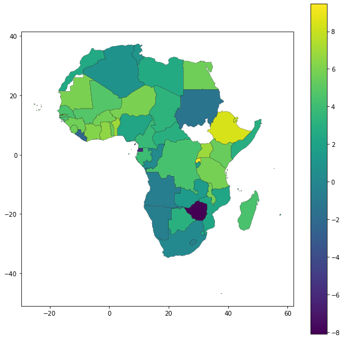

```python
africagdp.plot(column="GDP_2019",
            edgecolor="black", lw=0.25,
            figsize=(10,10),cmap='viridis',legend=True, )
plt.show()
```

##### This sheet in the file consist of GDV values of each year of each country

```python
#GLobal
df_gdp = pd.read_excel(r'GDP/Data_Extract_From_World_Development_Indicators-3.xlsx', sheet_name='Data')
df_gdpAfrica = df_gdp.copy()
df_gdp.head()
```

|  | Series Name | Series Code | Country Name | Country Code | 1990 [YR1990] | 2000 [YR2000] | 2011 [YR2011] | 2012 [YR2012] | 2013 [YR2013] | 2014 [YR2014] | 2015 [YR2015] | 2016 [YR2016] | 2017 [YR2017] | 2018 [YR2018] | 2019 [YR2019] | 2020 [YR2020] |
| --- | --- | --- | --- | --- | --- | --- | --- | --- | --- | --- | --- | --- | --- | --- | --- | --- |
| 0 | GDP (current US$) | NY.GDP.MKTP.CD | Sub-Saharan Africa | SSF | 333833598083.06134 | 422926100652.814819 | 1613384684446.109619 | 1677242194703.106934 | 1784347945822.364502 | 1835235792265.853027 | 1679376809348.154297 | 1562566509447.554199 | 1667997124634.602051 | 1753414899266.081299 | 1802947974476.532471 | 1703403090966.087646 |
| 1 | GDP (current US$) | NY.GDP.MKTP.CD | Angola | AGO | 11236275842.735785 | 9129634978.337732 | 111789686464.441299 | 128052853643.105545 | 136709862831.19368 | 145712200312.505066 | 116193649124.151367 | 101123851090.455368 | 122123822333.5905 | 101353230784.593735 | 89417190341.253281 | 58375976292.967789 |
| 2 | GDP (current US$) | NY.GDP.MKTP.CD | Benin | BEN | 1959965243.76269 | 3519991326.484636 | 10693321953.635511 | 11141358945.134943 | 12517845732.209541 | 13284528654.057367 | 11388160958.248966 | 11821066152.59795 | 12701654743.214926 | 14262407011.525412 | 14391686632.782114 | 15651545331.540379 |
| 3 | GDP (current US$) | NY.GDP.MKTP.CD | Botswana | BWA | 3790567051.867777 | 5788329609.157553 | 15351972361.147671 | 14380004175.119429 | 14901750991.201229 | 15654660710.107952 | 13578754072.4652 | 15082578064.800207 | 16088437675.164776 | 16914245098.039217 | 16593720655.64016 | 15061922801.627066 |
| 4 | GDP (current US$) | NY.GDP.MKTP.CD | Burkina Faso | BFA | 3101300641.875116 | 2968369991.467288 | 12080296644.064301 | 12561016091.467287 | 13444301139.138399 | 13943016923.901682 | 11832159275.60297 | 12833363370.174025 | 14106956830.085659 | 15890065019.76338 | 16178162030.069414 | 17933606353.177456 |

```python
df_gdp.drop(columns = ['Series Name','Series Code'], inplace = True)
```

```python
df_gdp = pd.melt(df_gdp, id_vars=['Country Name' , 'Country Code'], var_name='Year', value_name='GDP')
df_gdp['Year'] = df_gdp['Year'].str.split().str[0].astype(int)
df_gdp.head()
```

|  | Country Name | Country Code | Year | GDP |
| --- | --- | --- | --- | --- |
| 0 | Sub-Saharan Africa | SSF | 1990 | 333833598083.06134 |
| 1 | Angola | AGO | 1990 | 11236275842.735785 |
| 2 | Benin | BEN | 1990 | 1959965243.76269 |
| 3 | Botswana | BWA | 1990 | 3790567051.867777 |
| 4 | Burkina Faso | BFA | 1990 | 3101300641.875116 |

Merging with stunting dataframe that has the Stunting data since 2000 - with country code and year

```python
df_stunting = df_gdp.merge(df_stunting,
                                  how='left',
                                  left_on=['Country Code', 'Year'],
                                  right_on=['ISO code', 'Year'])
df_stunting.head()
```

|  | Country Name | Country Code | Year | GDP | ISO code | Country and areas | Indicator | Measure | Affected- Lower Uncertainty Bound | Affected- Point Estimate | Affected- Upper Uncertainty Bound |
| --- | --- | --- | --- | --- | --- | --- | --- | --- | --- | --- | --- |
| 0 | Sub-Saharan Africa | SSF | 1990 | 333833598083.06134 | NaN | NaN | NaN | NaN | NaN | NaN | NaN |
| 1 | Angola | AGO | 1990 | 11236275842.735785 | NaN | NaN | NaN | NaN | NaN | NaN | NaN |
| 2 | Benin | BEN | 1990 | 1959965243.76269 | NaN | NaN | NaN | NaN | NaN | NaN | NaN |
| 3 | Botswana | BWA | 1990 | 3790567051.867777 | NaN | NaN | NaN | NaN | NaN | NaN | NaN |
| 4 | Burkina Faso | BFA | 1990 | 3101300641.875116 | NaN | NaN | NaN | NaN | NaN | NaN | NaN |

Data transformation done on data to plot graphs to visualize and understand the trends

```python
df_stunting[['Year', ]] = df_stunting[['Year']].astype(int)
df_stunting.dropna(inplace=True)
df_stunting.drop(df_stunting[df_stunting['GDP']=='..'].index, inplace=True)
df_stunting.drop(df_stunting[df_stunting['Affected- Point Estimate']=='..'].index, inplace=True)

df_stunting[['GDP', 'Affected- Point Estimate']] = df_stunting[['GDP', 'Affected- Point Estimate']].astype(float)
```

```python
df_stunting2019 = df_stunting[df_stunting['Year']==2019]
```

```python
df_stunting2019[['GDP', 'Affected- Point Estimate']] = df_stunting2019[['GDP', 'Affected- Point Estimate']].astype(float)
```

##### The below figure show the GDP of each country along with how much is the stunting numbers in each country for the year 2019

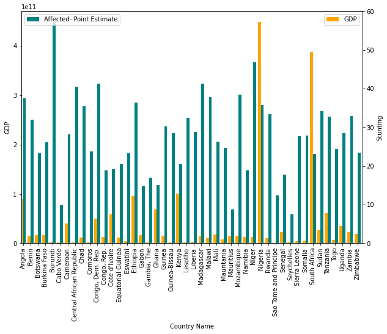

```python
plt.rcParams['figure.figsize'] = (10,7)

fig = plt.figure() # Create matplotlib figure

ax = fig.add_subplot(111) # Create matplotlib axes
ax2 = ax.twinx() # Create another axes that shares the same x-axis as ax.

width = 0.4

df_stunting2019.plot(kind='bar',x='Country Name', y = 'GDP' , color='orange', ax=ax, width=width, position=1,)
df_stunting2019.plot(kind='bar',x='Country Name' ,y = 'Affected- Point Estimate', color='teal', ax=ax2, width=width, position=0)

# plt.xticks(df_stunting_gdp2019['Country Name'])
ax.set_ylabel('GDP')
ax2.set_ylabel('Stunting')
ax.legend(loc=0)
ax2.legend(loc=2)

plt.savefig('GDP2019_Africa.svg',bbox_inches='tight')

plt.show()
```

```python
df_stunting_gdp = df_stunting[df_stunting['Year']!=2020]
df_stunting_gdp.head()
```

|  | Country Name | Country Code | Year | GDP | ISO code | Country and areas | Indicator | Measure | Affected- Lower Uncertainty Bound | Affected- Point Estimate | Affected- Upper Uncertainty Bound |
| --- | --- | --- | --- | --- | --- | --- | --- | --- | --- | --- | --- |
| 55 | Angola | AGO | 2000 | 9.129635e+09 | AGO | Angola | Stunting | Proportion | 44.3 | 47.8 | 51.4 |
| 56 | Benin | BEN | 2000 | 3.519991e+09 | BEN | Benin | Stunting | Proportion | 34.3 | 36.8 | 39.5 |
| 57 | Botswana | BWA | 2000 | 5.788330e+09 | BWA | Botswana | Stunting | Proportion | 29.2 | 31.5 | 33.9 |
| 58 | Burkina Faso | BFA | 2000 | 2.968370e+09 | BFA | Burkina Faso | Stunting | Proportion | 38.6 | 41.5 | 44.5 |
| 59 | Burundi | BDI | 2000 | 8.704861e+08 | BDI | Burundi | Stunting | Proportion | 58.8 | 62.3 | 65.7 |

### Research Question 3

#### How have the countries with the highest malnutrition rates fared over time, and has there been any progress?

##### The below figure illustrates the trend of GDP and stunting over the years (2000 - 2019)

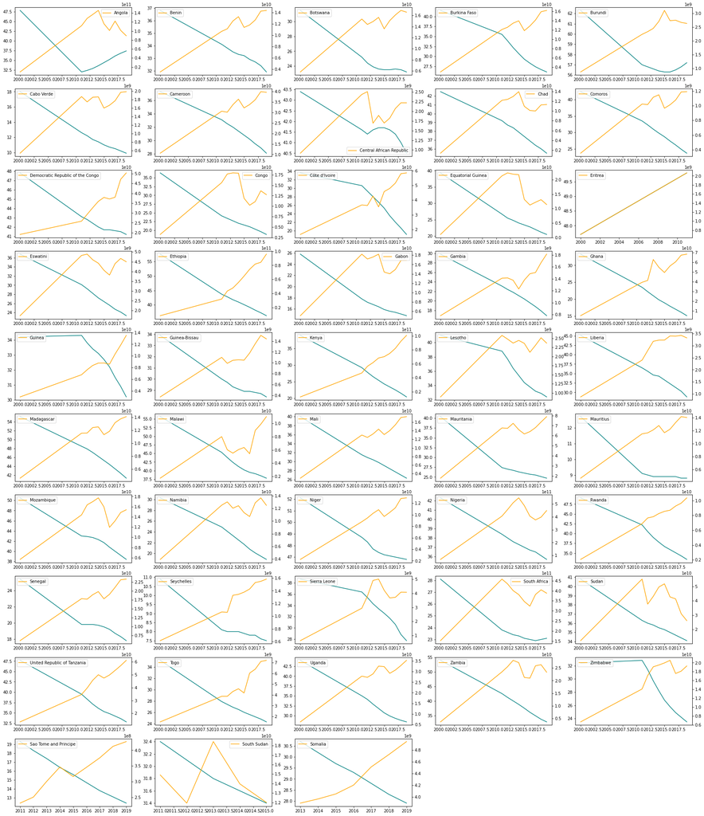

```python
plt.figure(figsize=(30,40), facecolor='white')
plotnumber = 1
plt.rcParams['figure.figsize'] = (5,5)
cou = df_stunting_gdp['Country and areas'].unique()
for i in cou:


    ax = plt.subplot(11, 5,plotnumber)
    df = df_stunting_gdp[df_stunting_gdp['Country and areas']==i]

    #fig, ax1 = plt.subplots()
    ax.plot(df['Year'], df['Affected- Point Estimate'],color = 'teal')

    ax2 = ax.twinx()

    ax2.plot(df['Year'], df['GDP'], color = 'orange')
    ax2.legend(df['Country and areas'])
    #ax2.legend('GDP')

    plotnumber+=1
plt.show()

gdpchangeList = ['Angola', 'Burundi', 'Central African Republic','South Africa' ]
```

##### As it id difficult to explore in depth with all countries data, countries with change in malnutrition rate in the last few years were selected

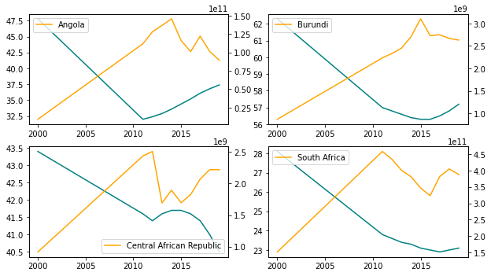

```python
gdpchangeList = ['Angola', 'Burundi', 'Central African Republic','South Africa' ]
df_stunting_gdp['Year'] = df_stunting_gdp['Year'].astype(int)
plt.figure(figsize=(10,15), facecolor='white')
plotnumber = 1
plt.rcParams['figure.figsize'] = (5,5)
for i in gdpchangeList:


    ax = plt.subplot(5,2,plotnumber)
    df = df_stunting_gdp[df_stunting_gdp['Country and areas'] == i]

    #fig, ax1 = plt.subplots()
    ax.plot(df['Year'], df['Affected- Point Estimate'],color = 'teal')

    ax2 = ax.twinx()

    ax2.plot(df['Year'], df['GDP'], color = 'orange')
    ax2.legend(df['Country and areas'])
    #ax2.legend('GDP')
    plt.locator_params(axis="x", integer=True, tight=True)

    plotnumber+=1


plt.savefig('GDP2000to2019_Africa.svg',bbox_inches='tight')
plt.show()
```

```python
df_GDPIG = df_gdp.merge(df_africa, left_on = 'Country Code', right_on = 'Country Code')
df_gdpcopy = df_GDPIG.copy()
df_GDPIG = df_GDPIG[(df_GDPIG['IncomeGroup'] == 'Lower middle income') &((df_GDPIG['Year'] != 2020)) ]
df_GDPIG.head()
```

|  | Country Name | Country Code | Year | GDP | Country | Population | Subregion | IncomeGroup |
| --- | --- | --- | --- | --- | --- | --- | --- | --- |
| 0 | Angola | AGO | 1990 | 11236275842.735785 | Angola | 32866272 | Middle Africa | Lower middle income |
| 1 | Angola | AGO | 2000 | 9129634978.337732 | Angola | 32866272 | Middle Africa | Lower middle income |
| 2 | Angola | AGO | 2011 | 111789686464.441299 | Angola | 32866272 | Middle Africa | Lower middle income |
| 3 | Angola | AGO | 2012 | 128052853643.105545 | Angola | 32866272 | Middle Africa | Lower middle income |
| 4 | Angola | AGO | 2013 | 136709862831.19368 | Angola | 32866272 | Middle Africa | Lower middle income |

```python
df_GDPIG['Year'] = df_GDPIG['Year'].astype(str)
df_GDPIG = df_GDPIG[~(df_GDPIG == '..').any(axis=1)]
df_GDPIG['GDP'] = df_GDPIG['GDP'].astype(float)
```

```python
df_GDPIG = pd.pivot(df_GDPIG, index = ['Country Name' , 'Country Code',  'Country', 'Population', 'Subregion', 'IncomeGroup'], columns = ['Year'])
df_GDPIG.head()
```

| Country Name | Country Code | Country | Population | Subregion | Year IncomeGroup | GDP 1990 | GDP 2000 | GDP 2011 | GDP 2012 | GDP 2013 | GDP 2014 | GDP 2015 | GDP 2016 | GDP 2017 | GDP 2018 | GDP 2019 |
| --- | --- | --- | --- | --- | --- | --- | --- | --- | --- | --- | --- | --- | --- | --- | --- | --- |
| Angola | AGO | Angola | 32866272 | Middle Africa | Lower middle income | 1.123628e+10 | 9.129635e+09 | 1.117897e+11 | 1.280529e+11 | 1.367099e+11 | 1.457122e+11 | 1.161936e+11 | 1.011239e+11 | 1.221238e+11 | 1.013532e+11 | 8.941719e+10 |
| Benin | BEN | Benin | 12123200 | Western Africa | Lower middle income | 1.959965e+09 | 3.519991e+09 | 1.069332e+10 | 1.114136e+10 | 1.251785e+10 | 1.328453e+10 | 1.138816e+10 | 1.182107e+10 | 1.270165e+10 | 1.426241e+10 | 1.439169e+10 |
| Cabo Verde | CPV | Cabo Verde | 555987 | Western Africa | Lower middle income | 3.068911e+08 | 5.392273e+08 | 1.865916e+09 | 1.741810e+09 | 1.850470e+09 | 1.859899e+09 | 1.596800e+09 | 1.662999e+09 | 1.768319e+09 | 1.966503e+09 | 1.981846e+09 |
| Cameroon | CMR | Cameroon | 26545863 | Middle Africa | Lower middle income | 1.231448e+10 | 1.056658e+10 | 3.063091e+10 | 3.015506e+10 | 3.372862e+10 | 3.638655e+10 | 3.221023e+10 | 3.381434e+10 | 3.609855e+10 | 3.997384e+10 | 3.967098e+10 |
| Comoros | COM | Comoros | 869601 | Eastern Africa | Lower middle income | 4.296221e+08 | 3.511366e+08 | 1.023086e+09 | 1.015843e+09 | 1.116224e+09 | 1.149588e+09 | 9.660295e+08 | 1.012836e+09 | 1.077440e+09 | 1.188798e+09 | 1.192560e+09 |

```python
df_GDPIG.columns = df_GDPIG.columns.droplevel(0)
df_GDPIG = df_GDPIG.reset_index()
df_GDPIG.head()
```

| Year | Country Name | Country Code | Country | Population | Subregion | IncomeGroup | 1990 | 2000 | 2011 | 2012 | 2013 | 2014 | 2015 | 2016 | 2017 | 2018 | 2019 |
| --- | --- | --- | --- | --- | --- | --- | --- | --- | --- | --- | --- | --- | --- | --- | --- | --- | --- |
| 0 | Angola | AGO | Angola | 32866272 | Middle Africa | Lower middle income | 1.123628e+10 | 9.129635e+09 | 1.117897e+11 | 1.280529e+11 | 1.367099e+11 | 1.457122e+11 | 1.161936e+11 | 1.011239e+11 | 1.221238e+11 | 1.013532e+11 | 8.941719e+10 |
| 1 | Benin | BEN | Benin | 12123200 | Western Africa | Lower middle income | 1.959965e+09 | 3.519991e+09 | 1.069332e+10 | 1.114136e+10 | 1.251785e+10 | 1.328453e+10 | 1.138816e+10 | 1.182107e+10 | 1.270165e+10 | 1.426241e+10 | 1.439169e+10 |
| 2 | Cabo Verde | CPV | Cabo Verde | 555987 | Western Africa | Lower middle income | 3.068911e+08 | 5.392273e+08 | 1.865916e+09 | 1.741810e+09 | 1.850470e+09 | 1.859899e+09 | 1.596800e+09 | 1.662999e+09 | 1.768319e+09 | 1.966503e+09 | 1.981846e+09 |
| 3 | Cameroon | CMR | Cameroon | 26545863 | Middle Africa | Lower middle income | 1.231448e+10 | 1.056658e+10 | 3.063091e+10 | 3.015506e+10 | 3.372862e+10 | 3.638655e+10 | 3.221023e+10 | 3.381434e+10 | 3.609855e+10 | 3.997384e+10 | 3.967098e+10 |
| 4 | Comoros | COM | Comoros | 869601 | Eastern Africa | Lower middle income | 4.296221e+08 | 3.511366e+08 | 1.023086e+09 | 1.015843e+09 | 1.116224e+09 | 1.149588e+09 | 9.660295e+08 | 1.012836e+09 | 1.077440e+09 | 1.188798e+09 | 1.192560e+09 |

```python
df_GDPIG.info()
```

```
<class 'pandas.core.frame.DataFrame'>
RangeIndex: 18 entries, 0 to 17
Data columns (total 17 columns):
 #   Column        Non-Null Count  Dtype
---  ------        --------------  -----
 0   Country Name  18 non-null     object
 1   Country Code  18 non-null     object
 2   Country       18 non-null     object
 3   Population    18 non-null     int64
 4   Subregion     18 non-null     object
 5   IncomeGroup   18 non-null     object
 6   1990          17 non-null     float64
 7   2000          17 non-null     float64
 8   2011          18 non-null     float64
 9   2012          18 non-null     float64
 10  2013          18 non-null     float64
 11  2014          18 non-null     float64
 12  2015          18 non-null     float64
 13  2016          18 non-null     float64
 14  2017          18 non-null     float64
 15  2018          18 non-null     float64
 16  2019          18 non-null     float64
dtypes: float64(11), int64(1), object(5)
memory usage: 2.5+ KB
```